# ANALYSIS AND INSIGHTS

## Udacity DAND: Wrangle and Analyze Data Project

### By: Jeeva Krishnasamy

### INTRODUCTION

This Wrangle and Analyze Data Project is part of Udacity’s Data Analyst Nanodegree. The project involves wrangling of data from various sources associated with tweets from the Twitter user @dog_rates, also known as WeRateDogs. WeRateDogs rate’s pictures of people’s dogs in a humorous manner, most often giving ratings higher than 10/10. After scraping together the data, quality and tidiness issues were assessed and then cleaned. Finally, two visualizations were created and insights can be found below.

### FAVORITE VS RETWEET COUNT

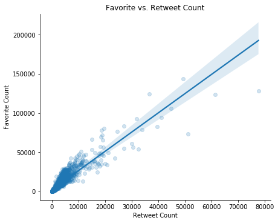

**Figure 1. Favorite count and retweet count from 2068 tweets from the Twitter user @dog_rates, also known as WeRateDogs.**

### STANDARDIZED RATING OVER TIME

The idea behind the WeRateDogs account is that they ask people to send them photos of their dogs, and they will rate them on a scale of 1-10 with humorous comments; however, they are often given ratings higher than 10. I assumed that almost all the dogs were given a rating higher than 10/10 but I was surprised to notice many with ratings lower than 10/10. In addition, many ratings did not have a denominator of 10. Therefore, to standardize the ratings I calculated a value of numerator divided by denominator. I was most curious to see if overtime, as the account became more popular and people associated the above 10/10 ratings with being funny, that the higher ratings would become more prevalent. Indeed, as shown in Figure 2, it appears that overtime the frequency of ratings below 1 decreases. Before 2016-11 there are many ratings below 1, while after that time there are barely any. The maximum standardized rating is about 1.3 except for three outliers including the joke ratings 1776/10 and 420/10 and 1 error that did not end up getting cleaned.

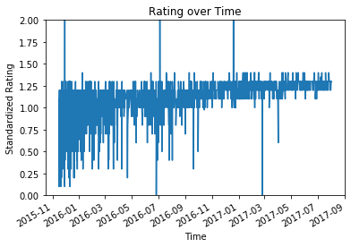

**Figure 2. Standardized rating over time from 2068 tweets from the Twitter user @dog_rates, also known as WeRateDogs.**